# Lab11. Correspondence analysis: CA and MCA

```r
# library(FactoMineR)
library(tidyverse)
library(ca)
library(vcd)
theme_set(theme_bw())
```

## Grammatical profiles of Russian verbs

In their article “Predicting Russian aspect by frequency across genres” Eckhoff et al. (2017) ask whether the aspect of individual verbs can be predicted based on the statistical distribution of their inflectional forms. The dataset contains a sample of sentences taken from the Russian National Corpus. Each verb was annotated by Mood&Tense, Voice, Aspect and other grammatical features.

```r
ru <- read.csv('https://raw.githubusercontent.com/agricolamz/2018-MAG_R_course/master/data/RNCverbSamples_journ.csv', sep=';')
str(ru)
```

```
## 'data.frame':    52716 obs. of  14 variables:
##  $ FormTranslit : Factor w/ 18861 levels "absorbirujuschimi",..: 5396 6884 18667 9730 6685 8847 554 5159 11780 13299 ...
##  $ LemmaTranslit: Factor w/ 5940 levels "absorbirovat'",..: 1718 2274 5887 3106 2212 2841 171 1633 3805 4229 ...
##  $ MoodTense    : Factor w/ 9 levels "gernonpast","gerpast",..: 6 6 6 6 6 5 8 7 7 8 ...
##  $ Trans        : Factor w/ 2 levels "intr","tran": 2 2 2 2 2 2 1 2 2 1 ...
##  $ Voice        : Factor w/ 4 levels "","act","med",..: 2 4 4 2 2 2 2 2 2 2 ...
##  $ VoicePartcp  : Factor w/ 3 levels "","act","pass": 1 3 3 1 1 1 2 1 1 2 ...
##  $ Person       : Factor w/ 4 levels "","1p","2p","3p": 1 1 1 1 1 4 1 1 1 1 ...
##  $ Number       : Factor w/ 3 levels "","pl","sg": 3 3 3 2 2 2 3 1 1 3 ...
##  $ Gender       : Factor w/ 4 levels "","f","m","n": 3 3 3 1 1 1 3 1 1 2 ...
##  $ Long         : Factor w/ 3 levels "","long","short": 1 3 3 1 1 1 2 1 1 2 ...
##  $ AspPair      : logi  NA NA NA NA NA NA ...
##  $ Aspect       : Factor w/ 2 levels "i","p": 2 2 2 1 2 1 1 1 1 1 ...
##  $ Mood         : Factor w/ 5 levels "ger","imper",..: 3 3 3 3 3 3 5 4 4 5 ...
##  $ Tense        : Factor w/ 4 levels "","fut","nonpast",..: 4 4 4 4 4 3 3 1 1 3 ...
```

First, we will do some preprocessing. Here, we join future passives with other passive participles.

```r
ru$MoodTense[ru$Voice == 'pass' & ru$MoodTense == 'indicfut'] <- "partcppast"
```

Let’s look at top-10 of verbs in the dataset

```r
ru %>%
  group_by(LemmaTranslit) %>%
  summarize(count=n()) %>%
  arrange(desc(count))
```

```
## # A tibble: 5,940 x 2
##    LemmaTranslit count
##    <fct>         <int>
##  1 byt'           2763
##  2 moch'          1125
##  3 stat'           820
##  4 govorit'        525
##  5 skazat'         432
##  6 znat'           334
##  7 imet'           328
##  8 sdelat'         320
##  9 poluchit'       316
## 10 schitat'        305
## # … with 5,930 more rows
```

### 1.1 Grammatical profiles

Grammatical profile is a vector that contains the number (or the ratio) of inflectional forms for individual lemmas. We can pick up a subset containing only forms of the verb *chitat’* ‘read’.

```r
ru.chit <- droplevels(subset(ru, LemmaTranslit == "chitat'"))
```

This is the grammatical profile of *chitat’*

```r
print("The grammatical profile of chitat'")
```

```
## [1] "The grammatical profile of chitat'"
```

```r
print(table(ru.chit$MoodTense))
```

```
##
##   gernonpast        imper     indicfut indicnonpast    indicpast          inf
##            2            8            1           15           14           22
```

```r
print(prop.table(table(ru.chit$MoodTense))*100)
```

```
##
##   gernonpast        imper     indicfut indicnonpast    indicpast          inf
##     3.225806    12.903226     1.612903    24.193548    22.580645    35.483871
```

Now we will calculate the grammatical profile of each verb (which has more than 50 occurrences in our data set) and split the resulting table into two parts: grammatical forms themselves (numeric data, see ttdata below) and metadata (categories labeled in the RNC or by annotators: lemma, trasitivity, aspect).

Table of tense-mood distribution per lemma:

```r
tab = table(ru$LemmaTranslit,ru$MoodTense)
#turns the table into a data frame
t = as.data.frame.matrix(tab)
#adds lemmas as a separate column
t$LemmaTranslit = row.names(t)
#adds metadata columns for transitivity and aspect, assuming that these are stable per lemma - just picking the first value per lemma
t$Trans = as.factor(unlist(lapply(t$LemmaTranslit, function(x) names(table(droplevels(subset(ru, LemmaTranslit == x)$Trans)))[1])))
t$Asp = as.factor(unlist(lapply(t$LemmaTranslit, function(x) names(table(droplevels(subset(ru, LemmaTranslit == x)$Aspect)))[1])))
```

Label the biaspectuals ‘b’:

```r
levels(t$Asp) <- c('i','p','b')
t[t$LemmaTranslit=="ispol'zovat'",]$Asp <- 'b'
t[t$LemmaTranslit=="obeschat'",]$Asp <- 'b'
```

Pick out the lemmas with 50 or more occurrences and split the data:

```r
tt <- t[rowSums(t[,1:9]) >= 50,]
```

## 1.2 t-SNE visualization (for numeric variables)

The idea behind this kind of visualisation is to plot different clusters as far from each other as possible (preserving the distance between each pair of clusters). Within each cluster, the points are distributed to show the internal structure of the cluster. Note that unlike PCA, in t-SNE the points’ coordinates cannot be interpreted directly (there is no linear mapping of one plane to another), and linear correlations can be misleading.

```r
library(Rtsne)
ru.tsne <- Rtsne(tt[,1:9],
                 dims=2,
                 perplexity=50,
                 verbose=TRUE,
                 max_iter = 2000)
```

[output not shown]

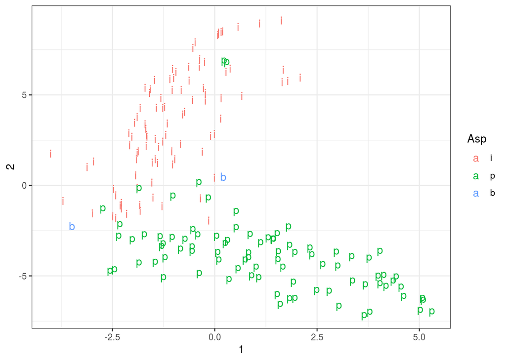

```r
tt <- cbind(tt, ru.tsne$Y)

tt %>%
  ggplot(aes(`1`, `2`, label = Asp, color = Asp))+
  geom_text()
```

## CA

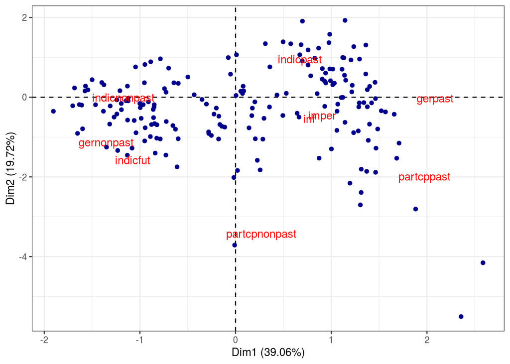

```r
tt_ca <- ca(tt[,1:9])

tt_col <- data.frame(tt_ca$colcoord)
tt_col$rows <- rownames(tt_ca$colcoord)

tt_row <- data.frame(tt_ca$rowcoord)
tt_row$rows <- rownames(tt_ca$rowcoord)

tt_col %>%
  ggplot(aes(Dim1, Dim2))+
  geom_hline(yintercept = 0, linetype = 2)+
  geom_vline(xintercept = 0,linetype = 2)+
  geom_point(data = tt_row, aes(Dim1, Dim2), color = "darkblue")+
  geom_text(aes(label = rows), color = "red")+
  labs(x = "Dim1 (39.06%)",
       y = "Dim2 (19.72%)")
```

## MCA

Dataset and description from [paper by Natalia Levshina](https://goo.gl/v6AmVj). Modern standard Dutch has two periphrastic causatives with the infinitive: the constructions with doen ‘do’ and laten ‘let’. The study is based on an 8-million token corpus of Netherlandic and Belgian Dutch. After the manual cleaning, there were left with 6,808 observations, which were then coded for seven semantic, syntactic, geographical and thematic variables.

```r
dutch_caus <- read.csv("https://goo.gl/2yAR3T")
MCA <- MASS::mca(dutch_caus[,-1])
MCA
```

```
## Call:
## MASS::mca(df = dutch_caus[, -1])
##
## Multiple correspondence analysis of 500 cases of 7 factors
##
## Correlations 0.577 0.458  cumulative % explained  9.62 17.25
```

```r
dutch_caus <- cbind(dutch_caus, MCA$rs)
variables <- as_data_frame(MCA$cs)
```

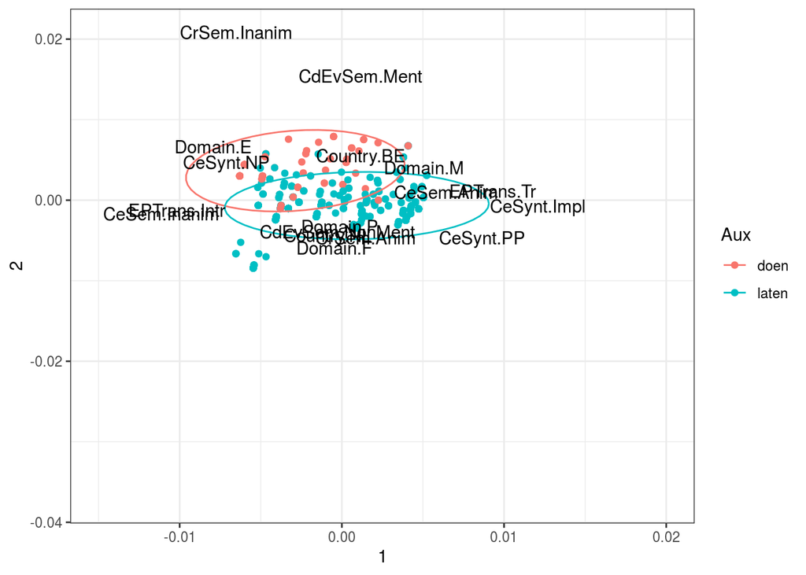

```r
variables$var_names <- rownames(MCA$cs)
dutch_caus %>%
  ggplot(aes(`1`, `2`))+
  geom_point(aes(color = Aux))+
  stat_ellipse(aes(color = Aux))+
  geom_text(data = variables, aes(`1`, `2`, label = var_names))+
  theme_bw()+
  scale_x_continuous(limits = c(-0.015, 0.02))
```